# Analysis of Bacterial Cell Yield Data

Fabian Roger

9 Oct 2015

**this script imports:**

- FlowCytoDocs/Bacterial_counts.txt #raw flow cytometry reading of bacterial cell abundances
- FlowCytoDocs/Timestamps_BacCounts.txt #timestamps of file readings
- FlowCytoDocs/TrueCounts_main.txt.txt #flow cyt. counts of truecounts as absolute reference
- FlowCytoDocs/TrueCounts_0614_HF.txt #truecount reference for one sample that has been read at different flowrate
- FlowCytoDocs/Timestamps_TrueCounts.txt #timestamp of truecount readings
- FlowCytoDocs/TrueCount Reference.txt #file that assigns the Truecounts to respective samples

**this script does:**

- quality control
- bias correction
- calculates maximum biomass per sample
- calculates temporal stability

**this script exports:**

data frames:

- response_var/maxBM.txt #maximum cell counts
- response_var/Stability.txt #temporal stability of the cell counts

the Gating:

[extract from my lab-book]

> I re-gate the data, based on a dot plot, a density plot showing 95% of the dots and 2 3D histograms. The aim is to gate everything besides the cluster in the lower left corner that is unlikely to be bacteria but some kind of “trash” (or viruses?). I will change the gate as little as possible. […] The Batch count is done […] with a file increament of 48, hence counting one Bottle chronologically at the time (to be consistent with the gating within one bottle). The Stats are exported in “Bac Counts DivTox 2nd counting”.

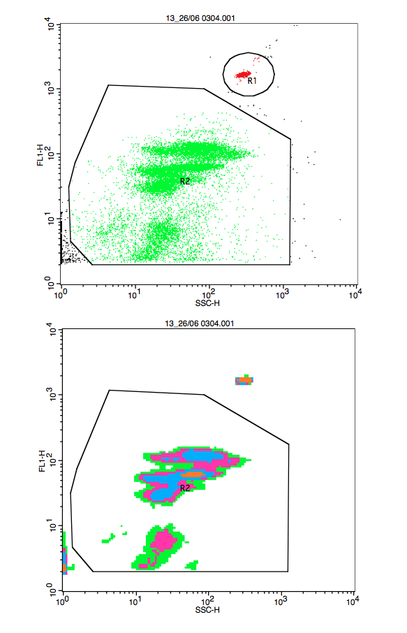

Example of the flow cyto gating. The upper graph shows the dot plot and the lower graph the density plot.

First, we import the file, clean it and have a look at it.

```
##               FileN  Acq.Date   G1    G2
## 1 01_02/06 0102.001 17-Sep-12 2097 31559
## 2 01_02/06 0203.001 17-Sep-12 2197  6447
```

The `$Gate` column of the file contains two gates, Gate **G1** correspond to region **R1** in the in the picture above and gates the beads that were added as internal standard.

The Gate **G2** correspond to region **R2** and gates the bacterial cells.

- I split up the information contained in the `$FileN` locum into three new columns
  - `$SO` is the sampling occasion ( 01 - 21)
  - `$DAT` is the sampling date (02/06 to 12/07)
  - `$BOT` is the number of the bottle that was sampled (01 - 48)
- I add a lake column `$Lake` to group the bottles into the respective lakes
- I add a column with the dilution factor for each bottle (`$DIL`)

The dilution factor represent the exponent of the dilution. Each dilution step was ~ 1 : 4.5. So the 10<sup>th</sup> dilution would be a 1 : 4.5<sup>10</sup> dilution and the dilution factor would be 10.  
The experiment had 10 dilution factors (0 - 10), and a sterile control. As the sterile control got invaded by (assumingly) environmental bacteria, we included it as treatment.

```r
head(Bac[ , -1], 2)
```

```
##    Acq.Date   G1    G2 SO   DAT BOT   Lake DIL
## 1 17-Sep-12 2097 31559 01 02/06  01 Lake 4   0
## 2 17-Sep-12 2197  6447 01 02/06  02 Lake 4  01
```

## checking the beads

We added 50µl of 1µm fluorescent beads solution with a known concentration into each sample as internal standard. The bead solution was sonnicated thoroughly at the beginning of each day and between each batch. However, the beads might have aggregated during the day or, to the contrary, aggregates that formed over night might have been broken up more and more during subsequent sonications. Both effect potentially biased the cell counts. To determine the concentration of the bead solution at the beginning of the day and after every second batch, we counted the beads with an absolute standard, BD Trucount<sup>TM</sup> Tubes, containing exactly 52187 beads.

In the following section, we used the exact timestemp of each raw flow cytometry file to asses biases over a day.

To visually check for biases, we plot the bead counts of each file against it’s acquisition time, split by acquisition day. To visualize the batches, we alternate the colors every 24 samples ( = the size of 1 batch ).

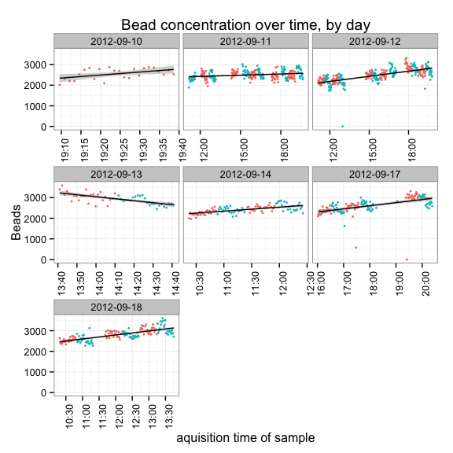

Looking at the graph above, it looks like the bead counts go up over the course of a day. While it is normal that the flow rate of the flow-cytometer varies randomly (as can be seen by the spread of the bead counts within each batch), the increase of the bead counts over the course of a day indicates that **concentration** of the bead solution changed. We have the BD Trucount<sup>TM</sup> counts to correct for this bias:

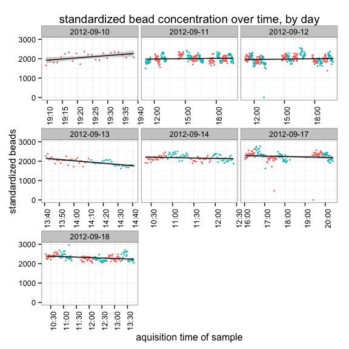

As we can see from the corrected bead counts above, the upwards trend disappeared. We conclude from that, that they standardization by the Trucounts<sup>TM</sup> worked.

Looking at the graph above, we can also see, that some bead counts are way below the average. To decide whether to exclude those points, we proceed with an outlier analysis.

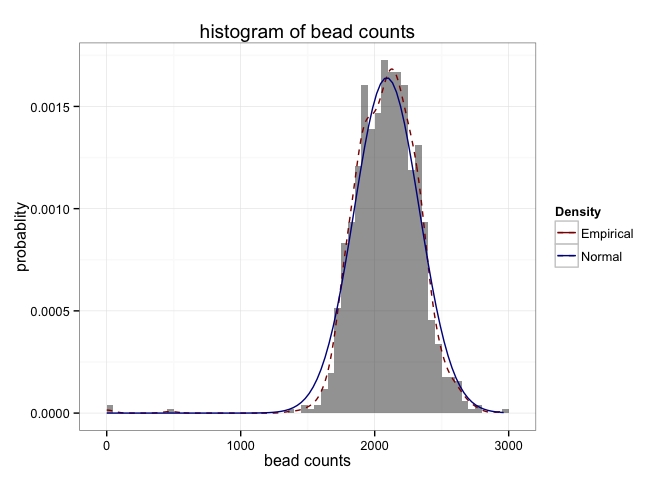

The distribution of the standardized bead counts looks normal, with 3 clear outliers. Let’s look at which samples these outliers represent.

```r
W <- which( Bac$G1 <= ( mean(BEAD) - 3 * sd( BEAD)))
Bac[W, c("DAT", "Lake", "DIL", "G1", "G2", "BeadC") ]
```

```
##            DAT   Lake DIL  G1    G2    BeadC
## 375 2012-06-28 Lake 1  02   0    10 175698.3
## 787 2012-06-04 Lake 2  06 573    64 179736.5
## 819 2012-06-06 Lake 4  02   1 13272 192390.9
```

For 2012-06-28 there are (almost) no bacterial counts and no bead counts. We exclude the sample.

For 2012-06-04 both the bead count and the cell number is low. This indicates that the flow rate was just exceptionally low. The resulting cell number is 2.007528310^{4}, which doesn’t seem unreasonable. We keep the sample *as is*.

For 2012-06-06 the cell counts are reasonable but the bead counts are absent. We replace the bead count by the average bead count of the 1 previous and the 2 following samples (run closely).

The following sample is missing and replaced by NA (spurious cell counts in `$G2`).

```
##            DAT   Lake DIL   G1  G2    BeadC
## 550 2012-07-06 Lake 2  09 1829 314 196976.1
```

Now that the data set is bias-corrected and cleaned, we can finally calculate the cell concentration in each sample. We will also drop all columns that are not needed for downstream analysis.

```r
Bac$Cells <- ( Bac$BeadC / Bac$G1) * Bac$G2
Bac <- Bac[ , c("BOT", "Lake", "DIL","DAT", "Cells")]
head(Bac, 3)
```

[output not shown]

## plotting the growth curves

Below, we plot the growth curves (Cells/ml for each day) for each lake. Within each lake, I plot one growth curve per dilution. The scale of the y-axis is held constant throughout the figures. The dashed lines represent the sampling occassions.

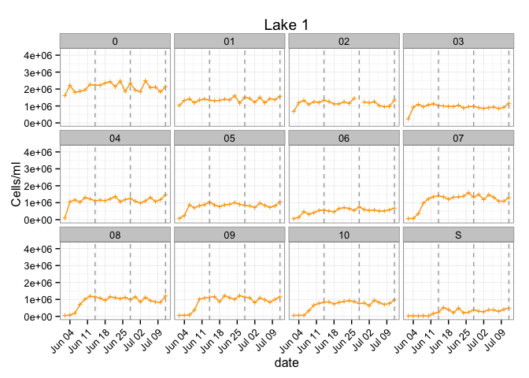

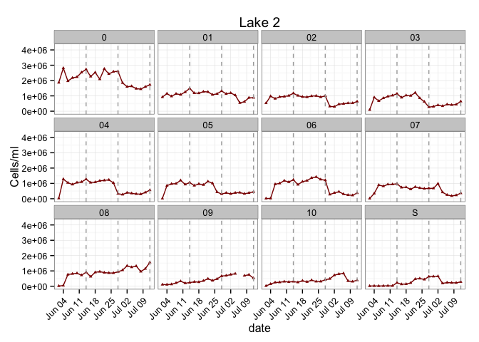

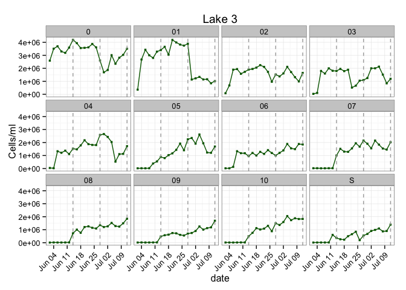

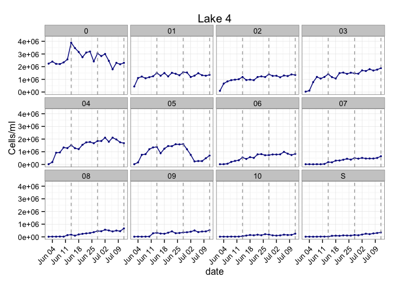

I also plot the growth curves together in one graph. This corresponds to **Figure_S4**

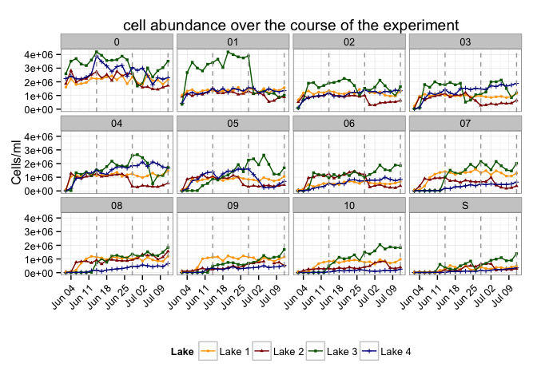

```r
ggsave("figures/Figure_S_4.pdf", Fig_S4, width = 8, height = 6)
```

## calculating maximum biomass and stability

From the growth data we extract two response variable that we use as ecosystem functions in our analysis:

- **maximum cell yield**
- **stability**

### maximum cell yield

We want to calculate the **maximum cell yield** as it should be representative of the total amount of resources that the bacterial communities could use. Our hypotheses is that more diverse communities will reach higher maximum cell yields than low diverse communities as they have the ability to use a greater share of the total available nutrients.

In order to minimize the influence of outliers, we take the average of the **5 highest cell yields** in each bottle as **maximum cell yield**

```r
maxBM <- Bac %>%
  group_by(BOT, Lake, DIL) %>%
  top_n(5, Cells) %>%
  summarise(maxCells = mean(Cells))

write.table(maxBM, "response_var/maxBM.txt", sep = "\t")
```

### stability

We want to calculate **stability** as we expect that a species-rich assemblage is more stable over time than a species poor one (portfolio effect).

As metric of stability we use the inverse of the coefficient of variance.

However, as the different dilutions start from different cell concentrations, we have to exclude the re-growth phase. By doing this we define stability as the *fluctuation of community cell yield around the mean of the stationary phase*

```r
Bac_stationary <- Bac[Bac$DAT > as.POSIXct("2012-06-12", tz = "GMT"),]
```

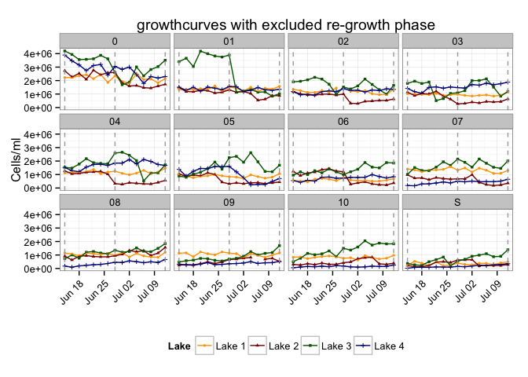

Looking at the graph of the stationary phase abundance, we can also see that some of the cultures experience a long-term trend. As we are only interested in looking how stable the culture is around the mean, we detrended the stationary phase cell abundance. For that, we fit a linear model of the form `Cells/ml ~ date` to the data and calculate the stability on the residuals. In order to avoid negative residuals we add the mean of the cell counts.

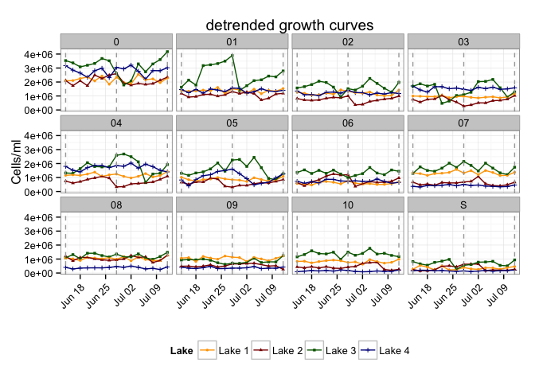

The detrending was successful and we can now proceed to calculate Stability. First we define a function to calculate the coefficient of variance (CV).

```r
co.var <- function(x) sd(x, na.rm=TRUE) / mean( x, na.rm=TRUE)
```

Then we calculate Stability as the inverse of the CV.

```r
Stability <- Bac_stationary %>%
  group_by(BOT, Lake, DIL) %>%
  summarise(Stability = 1/co.var(Resid))

write.table(Stability, "response_var/Stability.txt", sep = "\t")
```